# Lab 05 — Sampling and Bootstrap Distributions

## Exercise 3 — Stratified sampling (by month) → bootstrap distribution

**Task:** Build a **month-stratified** sample that takes the same number of observations per month.

This is one way to make your sample more representative when the population has strong seasonality.

```r
set.seed(480)

n_samp <- 240  # divisible by 12 makes this easy (20 per month)
k_per_month <- n_samp / 12

# 1) Create a month-stratified sample from df
df_strat <- df %>%
  filter(!is.na(swc)) %>%
  group_by(month) %>%
  slice_sample(n = k_per_month) %>%
  ungroup()

swc_samp_strat <- df_strat$swc

# CHECK:
df_strat %>% count(month)
```

| month | n |
| --- | --- |
| Jan | 20 |
| Feb | 20 |
| Mar | 20 |
| Apr | 20 |
| May | 20 |
| Jun | 20 |
| Jul | 20 |
| Aug | 20 |
| Sep | 20 |
| Oct | 20 |

[output cut: 3 more lines]

```r
set.seed(480)

B <- 4000

boot_means_strat <- replicate(
  B,
  mean(sample(swc_samp_strat, size = length(swc_samp_strat), replace = TRUE))
)

tibble(
  pop_mean = pop_mean_swc,
  sample_mean = mean(swc_samp_strat),
  boot_sd = sd(boot_means_strat)
)
```

| pop_mean | sample_mean | boot_sd |
| --- | --- | --- |
| 35.4762 | 35.09339 | 0.4911833 |

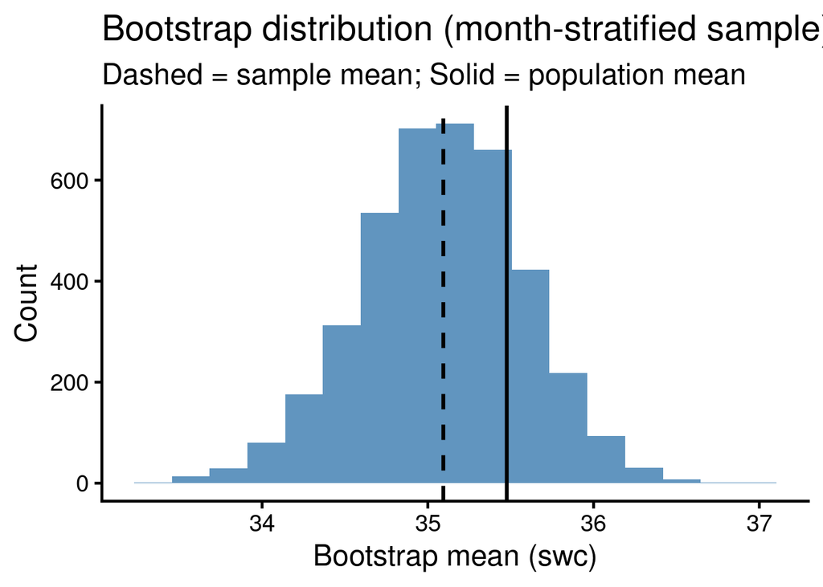

```r
# GOAL: Plot stratified bootstrap and compare to population mean.

tibble(boot_mean = boot_means_strat) %>%
  ggplot(aes(x = boot_mean)) +
  geom_histogram(bins = 17, alpha = 0.85, fill = "steelblue") +
  geom_vline(xintercept = mean(swc_samp_strat), linetype = "dashed", linewidth = 1.1) +
  geom_vline(xintercept = pop_mean_swc, linetype = "solid", linewidth = 1.1) +
  theme_classic(base_size = 18) +
  labs(
    x = "Bootstrap mean (swc)",
    y = "Count",
    title = "Bootstrap distribution (month-stratified sample)",
    subtitle = "Dashed = sample mean; Solid = population mean"
  )
```

**Prompt (4–6 sentences):** Compare the centers and spreads of the three bootstrap distributions (random vs summer-only vs stratified).  
Which sampling design is most accurate for the annual mean? Which looks most precise?  
What does this teach you about bootstrap and study design?

# Part II wrap-up

**One sentence to remember:**

> Bootstrap measures uncertainty around your estimate, **given your sample** — it cannot rescue a biased sample.

# Submission

- Knit your `.Rmd` to HTML.
- Commit and push both the `.Rmd` to your GitHub repo.

# Part III — Estimating 95% Confidence Intervals with Bootstrap

In this section you will use the bootstrap distributions you learned to create **95% confidence intervals**.

Recall:

A 95% bootstrap confidence interval can be estimated using the **2.5% and 97.5% quantiles** of the bootstrap distribution.

## Exercise 1 — 95% CI for the Mean (SWC)

Using the **random SWC sample from earlier**, compute a **95% bootstrap confidence interval for the mean**.

```r
# GOAL: compute the 2.5% and 97.5% quantiles of the bootstrap distribution

quantile(boot_means_random, probs = c(0.025, 0.975))
```

```
##     2.5%    97.5%
## 34.76085 36.93874
```

**Prompt:**

Does the confidence interval contain the **true population mean (`pop_mean_swc`)**?  
What does this tell you about the uncertainty of the estimate?

> - Yes, the confidence interval contains the true population mean. This tells us that the uncertainty of the bootstrap estimate is aligned with the population mean in a well enough confidence interval to be applicable in science.

## Exercise 2 — Visualizing the Confidence Interval

Modify the bootstrap histogram from Part II so that the **95% CI is shown on the plot**.

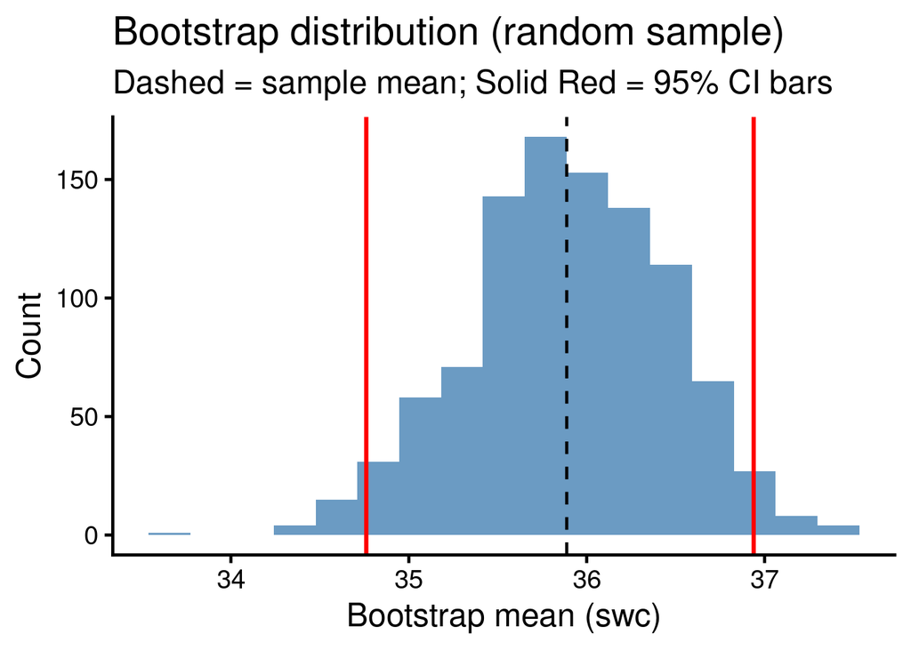

```r
boot_ci <- quantile(boot_means_random, probs = c(0.025, 0.975))

tibble(boot_mean = boot_means_random) %>%
  ggplot(aes(x = boot_mean)) +
  geom_histogram(bins = 17, alpha = 0.8, fill = "steelblue") +
  geom_vline(xintercept = boot_ci, color = "red", linewidth = 1.1) +
  geom_vline(xintercept = mean(swc_samp_random), linetype = "dashed") +
  theme_classic(base_size = 18) +
  labs(
    x = "Bootstrap mean (swc)",
    y = "Count",
    title = "Bootstrap distribution (random sample)",
    subtitle = "Dashed = sample mean; Solid Red = 95% CI bars"
  )
```

**Prompt:**

Explain what the **red vertical lines** represent.

> - The red vertical lines represent the range of values within 95% confidence of the mean. Any value outside of the space inbetween the red lines is NOT within 95% confidence

## Exercise 3 — Confidence Intervals for a Linear Model

Choose:

- one **response variable**
- one **predictor variable**

from the dataset.

Examples:

- `swc ~ ta`
- `swc ~ le`
- `gpp ~ ta`

```r
response_var <- "gpp"
predictor_var <- "ta"

model <- lm(df[[response_var]] ~ df[[predictor_var]])

coef(model)
```

```
##         (Intercept) df[[predictor_var]]
##          -1.6611125           0.5744921
```

### Bootstrap the regression

```r
new_df <- df %>%
  slice_sample(n = 800, replace = FALSE)

set.seed(480)

B <- 1000

boot_coef <- replicate(B, {

  samp_rows <- new_df %>%
    slice_sample(n = nrow(new_df), replace = TRUE)

  fit <- lm( samp_rows[[response_var]] ~ samp_rows[[predictor_var]]
)
  coef(fit)

})

boot_coef <- t(boot_coef)
head(boot_coef, 20)
```

```
##       (Intercept) samp_rows[[predictor_var]]
##  [1,]   -1.633532                  0.6021127
##  [2,]   -1.520861                  0.5769387
##  [3,]   -1.412196                  0.5778839
##  [4,]   -1.976792                  0.6308282
##  [5,]   -1.587498                  0.5919584
##  [6,]   -1.463284                  0.5719867
##  [7,]   -1.426262                  0.5539861
##  [8,]   -1.430693                  0.5876109
##  [9,]   -1.422559                  0.6128683
## [10,]   -1.544013                  0.5785298
## [11,]   -1.428408                  0.5645736
## [12,]   -2.056991                  0.6434337
## [13,]   -1.754190                  0.5847301
## [14,]   -1.346499                  0.6009623
## [15,]   -1.683049                  0.5972703
## [16,]   -1.676448                  0.6235208
## [17,]   -1.608629                  0.6042275
## [18,]   -1.848960                  0.6542193
## [19,]   -1.404801                  0.5510468
## [20,]   -1.791185                  0.6146330
```

### Compute confidence intervals

```r
quantile(boot_coef[,1], probs = c(0.025, 0.975))  # intercept CI
```

```
##       2.5%      97.5%
## -2.1245913 -0.9419252
```

```r
quantile(boot_coef[,2], probs = c(0.025, 0.975))  # slope CI
```

```
##      2.5%     97.5%
## 0.5289483 0.6507866
```

**Prompt:**

Interpret the slope confidence interval.

- Does it include zero?
- What does that imply about the relationship between the predictor and response variable?
> - No, the slope does not include 0. This implies that the predictor and response variable have a positive relationship within a 95% confidence interval. Since my predictor is atmospheric temperature (ta), and my response variable is Gross Primary Productivity (gpp), it would make sense that there is more biological productivity with increasing temperatures.

# Submission

- Knit your `.Rmd` to HTML.
- Commit and push both the `.Rmd` to your GitHub repo.